# Données et quelques analyses : Does repetition increase perceived fakeness in a judgment context referring to social media? – pour TER L3, HPS6U26, AMU

- Show All Code
- Hide All Code
- View Source

Author

Jérémy Béna

Mis en ligne le :

March 27, 2024

## Ce document

Ce document présente les analyses et les résultats de l’étude non-publiée sur le fake news by repetition effect dont j’ai partagé le préenregistrement et une présentation plus tôt ce semestre pour le TER L3 HPS6U26.

Les données participants $*$ items et les données agrégées à chaque niveau participant $*$ condition pourront être téléchargées à partir de ce document. Vous pouvez les utiliser pour réaliser des analyses avec le logiciel JASP par exemple.

Dernier point : le code R qui sert à réaliser les opérations sur les données, à réaliser les tests statistiques, et à générer la figure est par défaut caché (et utilisé pour générer automatiquement les éléments de résultats rapportés). Pour le consulter (le code est en grande partie annoté), vous pouvez cliquer sur `Cliquer ici pour voir le code R` quand cette expression apparaît plus bas).

## Participants

**Cliquer ici pour voir le code R**

```r
#Load (or install and load) packages
require(pacman)
p_load('tidyverse', 'dplyr', 'psych')

# read the data file
dat = read.csv("data.csv")

# table(dat$consent)
# table(dat$serious)
# table(dat$pay_attention)

#Socio-demographic information
sociodemo = read.csv("sociodemographic_information.csv")

sociodemo = sociodemo %>% filter(Status=="APPROVED")
tab_sex = as.matrix(table(sociodemo$Sex)/219)
#describe(sociodemo$Age)
```

Sur les 220 participants qui ont participé à l’étude (sur la plateforme Prolific, étude en ligne ; les participants étaient rémunérés), nous avons collecté les données complètes de 219 participants (50$\%$ femmes; $M_{âge} =$ 38.77 ; $SD_{âge} =$ 15.21). Aucun participant n’était à exclure sur base des critères d’exclusion préenregistrés (déclaration de réponses au hasard ; déclaration de ne pas avoir fait attention aux consignes ou aux affirmations).

## Constitution du jeu de données pour les analyses

Voir le code `R` pour la constitution du jeu de données pour les analyses.

**Cliquer ici pour voir le code R**

```r
#Retrieve the statements ppts saw in the exposure phase and keep only the variables of interest
dat_exposure = dat %>%
  filter(sender == "exposure_trial") %>%
  select(url.srid, statements, Truth, encoding_phase)

##Check that the exposure phase worked as intended in the experiment: 20 different statements, half true and half false
#check whether all repeated statements appeared only once for each participant - should be the case
check_exp = table(dat_exposure$statements, dat_exposure$url.srid)
# table(check_exp>1) #should only be "false" - it is "false"

#In the exposure phase, do we have as many true and false participants at the aggregated level?
# table(dat_exposure$Truth) #yes

#and for each participant?
# table(dat_exposure$Truth, dat_exposure$url.srid) #yes, we find 10 true and 10 false statements for each participant

#say that the present statements are all repeated (because they were seen the exposure phase)
dat_exposure$repetition = "repeated"

#Retrieve the statements and responses from the test phase, and keep only the variables of interest
dat_judgment = dat %>%
  filter(sender == "judgment_trial") %>%
  select(url.srid, response, statements_judgment, Truth_judgment, judgment_phase, serious, pay_attention)

#rename the columns to have "statements" named in the same way in data_exposure and data_test
colnames(dat_judgment) = c("url.srid", "response", "statements", "Truth", "judgment_phase", "check_seriousness", "check_attention")

#we make one data set with data_exposure and data_test, merging by ID and statements
data_all = full_join(dat_judgment, dat_exposure
                     , by = c("url.srid" = "url.srid", "statements"="statements", "Truth" = "Truth"))

#statements that do not appear in the first session are new
data_all$repetition = replace_na(data_all$repetition, "new")

#check if same number of true and false statements in each Repetition condition
# table(data_all$Truth, data_all$repetition) #yes, the program worked as intended

data_all$url.srid = as.factor(data_all$url.srid)
data_all$response = as.factor(data_all$response)
data_all$statements = as.factor(data_all$statements)
data_all$Truth = as.factor(data_all$Truth)
data_all$repetition = as.factor(data_all$repetition)

#recode "fake news" judgments: if "resp_fake_news" : 1; else: 0
data_all$fakeness_judg = ifelse(data_all$response == "resp_fake_news", 1,0)

#save the final data set, but first rename the columns
colnames(data_all) = c("ppt", "response", "statement", "truth", "pos_judgment_phase", "check_seriousness", "check_attention", "pos_exposure_phase", "repetition", "fakeness_judg")

# data_all = data_all %>%
#   select(ppt, statement, truth, repetition, fakeness_judg)

# table(data_all$response, data_all$fakeness_judg)
# table(data_all$repetition, data_all$pos_exposure_phase)

#write the data file if needed
#write.csv(data_all, "data_all.csv")
```

## Jeu de données long participant $*$ item

Voici un aperçu du jeu de données (pour $N =$ 219 participants et $k = 40$ affirmations = 8760 lignes dans le jeu de données) :

**Cliquer ici pour voir le code R**

```r
p_load(DT)
datatable(data_all)
```

|  | ppt | response | statement | truth | pos_judgment_phase | check_seriousness | check_attention | pos_exposure_phase | repetition | fakeness_judg |
| --- | --- | --- | --- | --- | --- | --- | --- | --- | --- | --- |
| 1 | 7718 | resp_fake_news | Elvis and Priscilla Presley have a biological child. | true | 0 | 1 | 1 | 2 | repeated | 1 |
| 2 | 7718 | resp_fake_news | Nelson Mandela did boxing as a hobby. | true | 1 | 1 | 1 |  | new | 1 |
| 3 | 7718 | resp_fake_news | Apart from humans, gorillas have only leopards as natural enemies. | true | 2 | 1 | 1 | 9 | repeated | 1 |
| 4 | 7718 | resp_real_news | The form of government of the United Arab Emirates is a constitutional monarchy. | false | 3 | 1 | 1 |  | new | 0 |
| 5 | 7718 | resp_real_news | According to his own statement, Andy Warhol was bisexual. | false | 4 | 1 | 1 |  | new | 0 |
| 6 | 7718 | resp_real_news | The largest lithium deposits in the world are located in Bolivia. | true | 5 | 1 | 1 |  | new | 0 |
| 7 | 7718 | resp_real_news | Hugh Grant was twice convicted of public misdemeanor of sexual nature. | false | 6 | 1 | 1 | 5 | repeated | 0 |
| 8 | 7718 | resp_fake_news | Sinti and Roma originally come from India and Pakistan. | true | 7 | 1 | 1 |  | new | 1 |
| 9 | 7718 | resp_fake_news | Elon Musk was married three times. | true | 8 | 1 | 1 |  | new | 1 |
| 10 | 7718 | resp_real_news | The slogan of the European Union "United in diversity" is based on an internet survey among students. | false | 9 | 1 | 1 | 1 | repeated | 0 |

[output cut: 8750 more lines]

Ce jeu de données contient notamment les colonnes suivantes :

- ppt : identifiant de chaque participant
- statement : affirmation-cible
- truth : vérité de l’affirmation
- repetition : condition de répétition de l’affirmation
- fakeness_judg : jugement de fakeness (0 : ‘real news’ ; 1 : ‘fake news’) – redondant avec `response`, mais le codage binaire permet d’utiliser cette variable dans les analyses).

Vous pouvez télécharger ce jeu de données via le bouton ci-dessous :

{{< downloadthis data_all.csv "Télécharger les données" data_all dl-btn "database-fill-down" "info" >}}

## Autres jeux de données pour analyses de type ANOVA, tests t…

**Cliquer ici pour voir le code R**

```r
#load packages
p_load('afex', 'lme4', 'lmerTest', 'effectsize', 'sjstats', 'sjPlot', 'BayesFactor', 'ggeffects', 'bfrr', 'papaja')

data_all$ppt = as.factor(data_all$ppt)
data_all$response = as.factor(data_all$response)
data_all$statement = as.factor(data_all$statement)
data_all$truth = as.factor(data_all$truth)
data_all$repetition = as.factor(data_all$repetition)
data_all$fakeness_judg = as.numeric(data_all$fakeness_judg)
```

Créons un jeu de données avec les proportions de jugements ‘fake news’ pour chaque participant dans chaque condition de répétition à travers les 40 affirmations :

**Cliquer ici pour voir le code R**

```r
#first, compute the proportions of "fake news" judgments for each participant and separately for repeated and new statements
data_agg = data_all %>%
  group_by(repetition, ppt) %>%
  summarise(mean_fakenews = mean(fakeness_judg)) #compute mean proportions of "yes fake news" responses for each Repetition condition and for each participant

data_agg$repetition = as.factor(data_agg$repetition)
#data_agg$truth = as.factor(data_agg$truth)
data_agg$ppt = as.factor(data_agg$ppt)
```

Nous avons maintenant un jeu de données avec 438 lignes (deux pour chaque participant ; une ligne correspond à la proportion de jugements ‘fake news’ sur les affirmations répétées, et l’autre à la proportion de jugements ‘faje news’ sur les affirmations nouvelles) :

**Cliquer ici pour voir le code R**

```r
datatable(data_agg)
```

|  | repetition | ppt | mean_fakenews |
| --- | --- | --- | --- |
| 1 | new | 7473 | 0.75 |
| 2 | new | 7474 | 0.25 |
| 3 | new | 7475 | 0.45 |
| 4 | new | 7476 | 0.45 |
| 5 | new | 7477 | 0.4 |
| 6 | new | 7478 | 0.65 |
| 7 | new | 7479 | 0.5 |
| 8 | new | 7481 | 0.4 |
| 9 | new | 7482 | 0.75 |
| 10 | new | 7483 | 0.6 |

[output cut: 428 more lines]

Il est possible d’obtenir ce jeu de données au format ‘large’ pour l’utiliser dans JASP par exemple :

**Cliquer ici pour voir le code R**

```r
data_agg_wide = data_agg %>% pivot_wider(names_from = repetition
                                         ,values_from = "mean_fakenews")

datatable(data_agg_wide)
```

|  | ppt | new | repeated |
| --- | --- | --- | --- |
| 1 | 7473 | 0.75 | 0.6 |
| 2 | 7474 | 0.25 | 0.45 |
| 3 | 7475 | 0.45 | 0.15 |
| 4 | 7476 | 0.45 | 0.45 |
| 5 | 7477 | 0.4 | 0.55 |
| 6 | 7478 | 0.65 | 0.4 |
| 7 | 7479 | 0.5 | 0.6 |
| 8 | 7481 | 0.4 | 0.35 |
| 9 | 7482 | 0.75 | 0.45 |
| 10 | 7483 | 0.6 | 0.6 |

[output cut: 209 more lines]

Ce jeu de données simplifié peut être téléchargé ici (au format `.csv`) :

{{< downloadthis data_agg_wide.csv "Télécharger les données" data_agg_wide dl-btn "database-fill-down" "info" >}}

Au besoin, un jeu de données similaire peut être téléchargé en fonction de la vérité factuelle des affirmations, en plus de la répétition (ce qui donne quatre lignes par participant) :

**Cliquer ici pour voir le code R**

```r
#first, compute the proportions of "fake news" judgments for each participant and separately for repeated and new statements
data_agg_v = data_all %>%
  group_by(repetition, truth, ppt) %>%
  summarise(mean_fakenews = mean(fakeness_judg)) #compute mean proportions of "yes fake news" responses for each Repetition*Factual truth condition and for each participant

data_agg_v$repetition = as.factor(data_agg_v$repetition)
data_agg_v$truth = as.factor(data_agg_v$truth)
data_agg_v$ppt = as.factor(data_agg_v$ppt)
```

**Cliquer ici pour voir le code R**

```r
datatable(data_agg_v)
```

|  | repetition | truth | ppt | mean_fakenews |
| --- | --- | --- | --- | --- |
| 1 | new | false | 7473 | 0.9 |
| 2 | new | false | 7474 | 0.2 |
| 3 | new | false | 7475 | 0.4 |
| 4 | new | false | 7476 | 0.4 |
| 5 | new | false | 7477 | 0.5 |
| 6 | new | false | 7478 | 0.5 |
| 7 | new | false | 7479 | 0.4 |
| 8 | new | false | 7481 | 0.4 |
| 9 | new | false | 7482 | 0.9 |
| 10 | new | false | 7483 | 0.8 |

[output cut: 866 more lines]

Voici ce même jeu de données en format large :

**Cliquer ici pour voir le code R**

```r
data_agg_v_wide = data_agg_v %>% pivot_wider(names_from = c(repetition, truth)
                                         ,values_from = "mean_fakenews")

datatable(data_agg_v_wide)
```

|  | ppt | new_false | new_true | repeated_false | repeated_true |
| --- | --- | --- | --- | --- | --- |
| 1 | 7473 | 0.9 | 0.6 | 0.7 | 0.5 |
| 2 | 7474 | 0.2 | 0.3 | 0.4 | 0.5 |
| 3 | 7475 | 0.4 | 0.5 | 0.1 | 0.2 |
| 4 | 7476 | 0.4 | 0.5 | 0.4 | 0.5 |
| 5 | 7477 | 0.5 | 0.3 | 0.6 | 0.5 |
| 6 | 7478 | 0.5 | 0.8 | 0.5 | 0.3 |
| 7 | 7479 | 0.4 | 0.6 | 0.6 | 0.6 |
| 8 | 7481 | 0.4 | 0.4 | 0.3 | 0.4 |
| 9 | 7482 | 0.9 | 0.6 | 0.3 | 0.6 |
| 10 | 7483 | 0.8 | 0.4 | 0.6 | 0.6 |

[output cut: 209 more lines]

Vous pouvez le télécharger ici :

{{< downloadthis data_agg_v_wide.csv "Télécharger les données" data_agg_v_wide dl-btn "database-fill-down" "info" >}}

## Quelques analyses statistiques et une figure

Ces jeux de données permettent des analyses telles que des tests $t$, ou ANOVA par exemple. Je présente des éléments de cette stratégie d’analyse ci-dessous. Les analyses préenregistrées (autres analyses fréquentistes, dont modèle mixte ; analyses bayésiennes) ne sont pas présentées.

**Cliquer ici pour voir le code R**

```r
mod1 = aov_ez(id = "ppt"
             ,dv = "mean_fakenews"
             ,within = c("repetition", "truth")
             ,data = data_agg_v)

report_mod1 = apa_print(mod1)
```

Nous avons réalisé une ANOVA 2 (Répétition) $*$ 2 (Vérité factuelle) sur les proportions de jugements “fake news”. L’effet principal de la répétition est significatif, $F(1, 218) = 5.76$, $p = .017$, $\hat{\eta}^2_G = .007$, 90% CI $[.000, .036]$. De façon intéressante, la proportion de jugements ‘fake news’ était **inférieure** pour les affirmations répétées ($M =$ 0.41 ; $SD =$ 0.15) par rapport à nouvelles ($M =$ 0.44 ; $SD =$ 0.15). L’effet principal de la vérité factuelle n’est pas significatif, $F(1, 218) = 1.50$, $p = .222$, $\hat{\eta}^2_G = .001$, 90% CI $[.000, .020]$. L’effet d’interaction entre la répétition et la vérité factuelle n’est pas significatif, $F(1, 218) = 0.79$, $p = .374$, $\hat{\eta}^2_G = .001$, 90% CI $[.000, .016]$. La figure ci-dessous présente l’effet de la répétition sur les proportions de jugements ‘fake news’.

**Cliquer ici pour voir le code R**

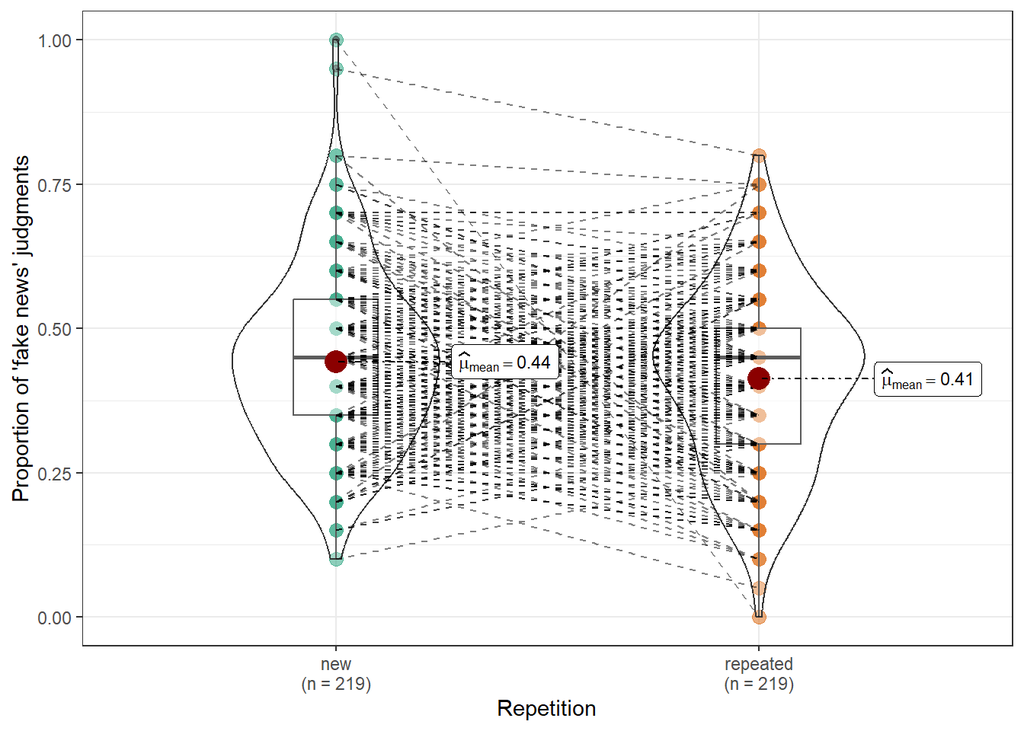

Proportion de jugements ‘fake news’ en fonction de la répétition

```r
p_load('ggstatsplot')

ggwithinstats(data = data_agg
                      ,subject.id = ppt
                      ,x = repetition
                      ,y = mean_fakenews
                      ,results.subtitle = TRUE
                      ,ggtheme = theme_bw()
                      ,bf.message = FALSE
                      ,centrality.type = "mean"
                      ,centrality.path=FALSE
                      ,xlab = "Repetition"
                      ,ylab = "Proportion of 'fake news' judgments"
)
```